# Untitled

Daniel Newman

1 September 2016

# Significant accuracy difference in behavioural accuracy between Older and Younger participants?

Accuracy distributions have negitive skew so do non-parametric repeated measures permutation test:

```
## [1] 71.2
```

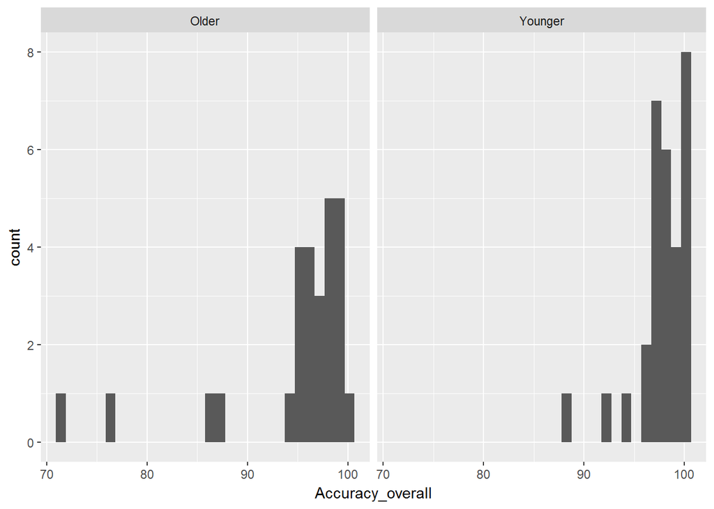

```
## [1] "Factorial Permutation test for the effect of Group on Accuracy:"
```

```
##   Effect     p p<.05
## 1  Group 0.026     *
```

```
## [1] 97.8
```

```
## [1] 94.8
```

**So this ^ shows the older participants had significantly lower accuracy than the younger**

# Healthy younger participants have significant leftward RT asymmetry, and the older participants do not

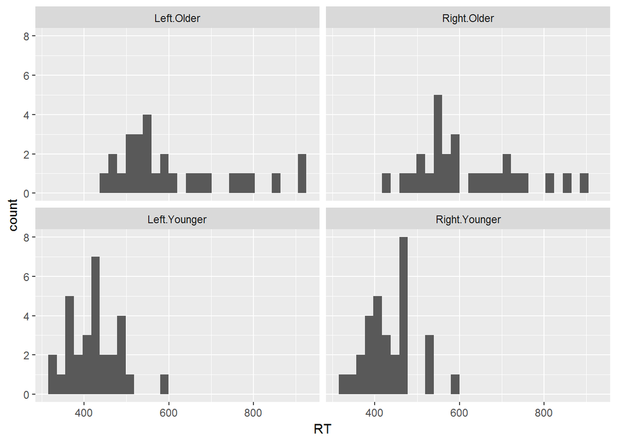

```
## [1] "Factorial Permutation test for the effect of Hemifield inside Younger only:"
```

```
##      Effect p p<.05
## 1 Hemifield 0     *
```

```
## [1] "Factorial Permutation test for the effect of Hemifield inside Older only:"
```

```
##      Effect     p p<.05
## 1 Hemifield 0.379
```

[output not shown]

# However, the difference in RT-asymmetry between the Older and Younger groups is not significant:

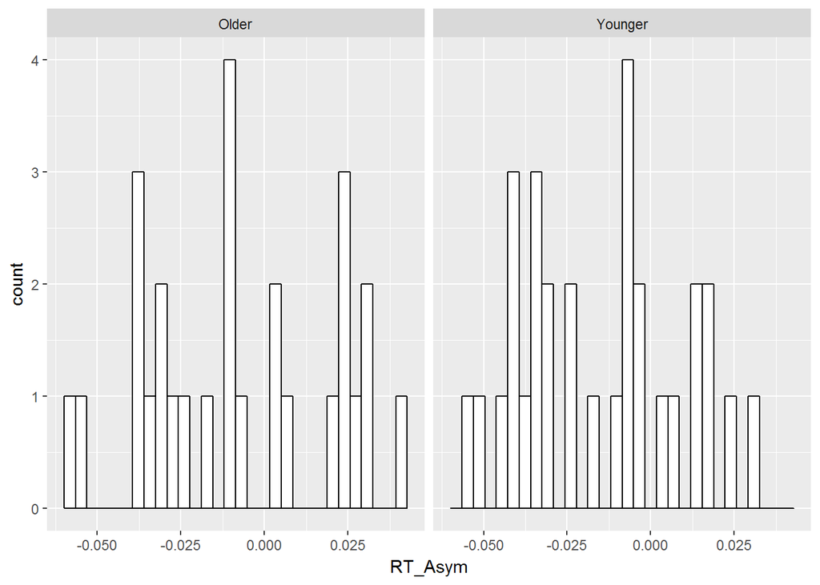

Mean RT Asym per group

| Group | RT_Asym.mean |
| --- | --- |
| Older | -0.0074 |
| Younger | -0.0151 |

```
##
##  Welch Two Sample t-test
##
## data:  participant_level$RT_Asym by participant_level$Group
## t = 1, df = 50, p-value = 0.3
## alternative hypothesis: true difference in means is not equal to 0
## 95 percent confidence interval:
##  -0.00638  0.02186
## sample estimates:
##   mean in group Older mean in group Younger
##              -0.00736              -0.01510
```

```
## [1] "Factorial Permutation test for the effect of Group on RT_Asym:"
```

```
##   Effect     p p<.05
## 1  Group 0.268
```

```
## [1] "Factorial Permutation test for the Group*Hemifield effect on RT:"
```

```
##            Effect     p p<.05
## 1           Group 0.000     *
## 2       Hemifield 0.014     *
## 3 Group:Hemifield 0.412
```

```
##
##  One Sample t-test
##
## data:  participant_level$RT_Asym[participant_level$Group == "Younger"]
## t = -3, df = 30, p-value = 0.002
## alternative hypothesis: true mean is not equal to 0
## 95 percent confidence interval:
##  -0.02421 -0.00599
## sample estimates:
## mean of x
##   -0.0151
```

```
##
##  One Sample t-test
##
## data:  participant_level$RT_Asym[participant_level$Group == "Older"]
## t = -1, df = 30, p-value = 0.2
## alternative hypothesis: true mean is not equal to 0
## 95 percent confidence interval:
##  -0.01855  0.00383
## sample estimates:
## mean of x
##  -0.00736
```

# Look for participant level outliers in RT and RT-asymmetry

```r
#calculate RT_Asym.Z inside Group and save it
m <- tapply(participant_level$RT_Asym,participant_level$Group,mean, na.rm = T)
s <- tapply(participant_level$RT_Asym,participant_level$Group,sd, na.rm = T)
participant_level$RT_Asym.Z <- (participant_level$RT_Asym-m[participant_level$Group])/s[participant_level$Group]

#calculate RT_Left.Z inside Group and save it
m <- tapply(participant_level$RT_Left,participant_level$Group,mean, na.rm = T)
s <- tapply(participant_level$RT_Left,participant_level$Group,sd, na.rm = T)
participant_level$RT_Left.Z <- (participant_level$RT_Left-m[participant_level$Group])/s[participant_level$Group]

#calculate RT_Right.Z inside Group and save it
m <- tapply(participant_level$RT_Right,participant_level$Group,mean, na.rm = T)
s <- tapply(participant_level$RT_Right,participant_level$Group,sd, na.rm = T)
participant_level$RT_Right.Z <- (participant_level$RT_Right-m[participant_level$Group])/s[participant_level$Group]



#calculate N2c_LeftTarget.Z inside Group and save it
m <- tapply(participant_level$N2c_LeftTarget,participant_level$Group,mean, na.rm = T)
s <- tapply(participant_level$N2c_LeftTarget,participant_level$Group,sd, na.rm = T)
participant_level$N2c_LeftTarget.Z <- (participant_level$N2c_LeftTarget-m[participant_level$Group])/s[participant_level$Group]

#calculate N2c_RightTarget.Z inside Group and save it
m <- tapply(participant_level$N2c_RightTarget,participant_level$Group,mean, na.rm = T)
s <- tapply(participant_level$N2c_RightTarget,participant_level$Group,sd, na.rm = T)
participant_level$N2c_RightTarget.Z <- (participant_level$N2c_RightTarget-m[participant_level$Group])/s[participant_level$Group]



#Save the participant level file as SPSS data folr
library(haven)
write_sav(participant_level, file.path(getwd(), "participant_level_data.sav"))
```

# Try linear mixed model approach to test the Group x Hemifield effect on log(RTs) in the single trial data:

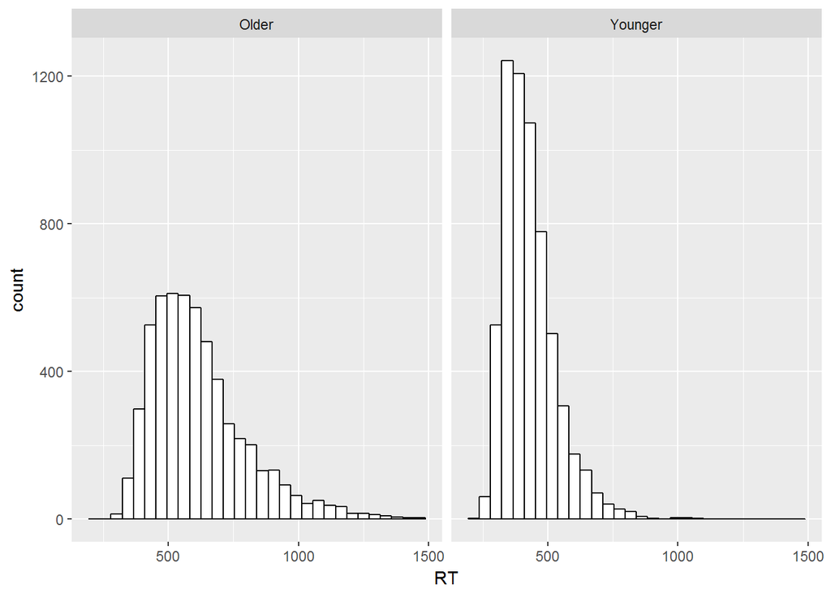

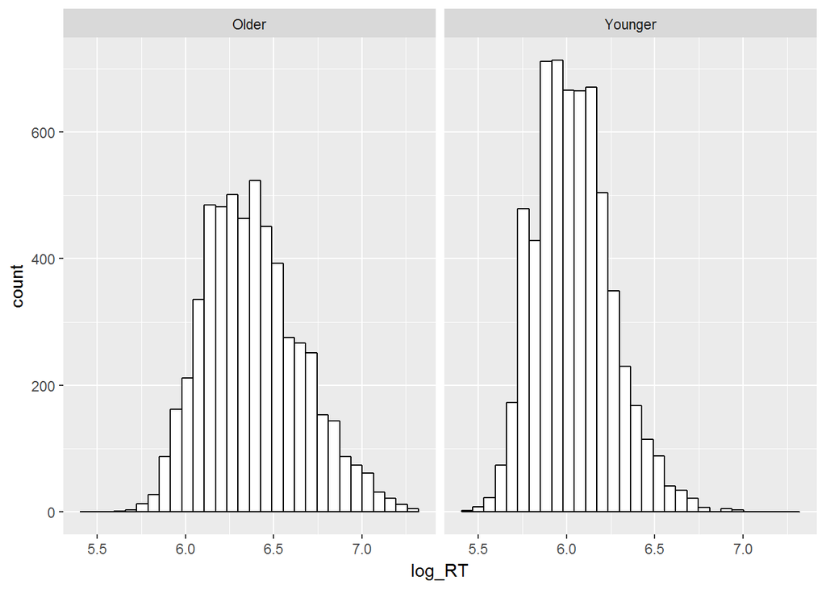

```
## Data: data2
## Models:
## RT_random_intercepts_only: log(RT) ~ 1 + (Hemifield | ID) + (1 | ITI) + (1 | MotionDirection) +
## RT_random_intercepts_only:     (1 | Trial)
## RT_Group: log(RT) ~ (Hemifield | ID) + (1 | ITI) + (1 | MotionDirection) +
## RT_Group:     (1 | Trial) + Group
## RT_Hemifield: log(RT) ~ (Hemifield | ID) + (1 | ITI) + (1 | MotionDirection) +
## RT_Hemifield:     (1 | Trial) + Group + Hemifield
## RT_HemifieldbyGroup: log(RT) ~ (Hemifield | ID) + (1 | ITI) + (1 | MotionDirection) +
## RT_HemifieldbyGroup:     (1 | Trial) + Group + Hemifield + Group:Hemifield
## RT_TOT: log(RT) ~ (Hemifield | ID) + (1 | ITI) + (1 | MotionDirection) +
## RT_TOT:     (1 | Trial) + Group + Hemifield + Trial + Group:Hemifield
## RT_TOTbyHemifield: log(RT) ~ (Hemifield | ID) + (1 | ITI) + (1 | MotionDirection) +
## RT_TOTbyHemifield:     (1 | Trial) + Group + Hemifield + Trial + Group:Hemifield +
## RT_TOTbyHemifield:     Hemifield:Trial
## RT_TOTbyGroup: log(RT) ~ (Hemifield | ID) + (1 | ITI) + (1 | MotionDirection) +
## RT_TOTbyGroup:     (1 | Trial) + Group + Hemifield + Trial + Group:Hemifield +
## RT_TOTbyGroup:     Hemifield:Trial + Group:Trial
## RT_TOTbyHemifieldbyGroup: log(RT) ~ (Hemifield | ID) + (1 | ITI) + (1 | MotionDirection) +
## RT_TOTbyHemifieldbyGroup:     (1 | Trial) + Group + Hemifield + Trial + Group:Hemifield +
## RT_TOTbyHemifieldbyGroup:     Hemifield:Trial + Group:Trial + Group:Hemifield:Trial
##                           Df   AIC   BIC logLik deviance Chisq Chi Df
## RT_random_intercepts_only  8 -6855 -6796   3435    -6871
## RT_Group                   9 -6895 -6828   3456    -6913 41.68      1
## RT_Hemifield              10 -6902 -6828   3461    -6922  9.13      1
## RT_HemifieldbyGroup       11 -6901 -6820   3462    -6923  1.62      1
## RT_TOT                    12 -6918 -6830   3471    -6942 18.83      1
## RT_TOTbyHemifield         13 -6920 -6825   3473    -6946  4.19      1
## RT_TOTbyGroup             14 -6935 -6831   3481    -6963 16.17      1
## RT_TOTbyHemifieldbyGroup  15 -6935 -6825   3483    -6965  2.64      1
##                              Pr(>Chisq)
## RT_random_intercepts_only
## RT_Group                  0.00000000011 ***
## RT_Hemifield                     0.0025 **
## RT_HemifieldbyGroup              0.2036
## RT_TOT                    0.00001431974 ***
## RT_TOTbyHemifield                0.0408 *
## RT_TOTbyGroup             0.00005784612 ***
## RT_TOTbyHemifieldbyGroup         0.1045
## ---
## Signif. codes:  0 '***' 0.001 '**' 0.01 '*' 0.05 '.' 0.1 ' ' 1
```

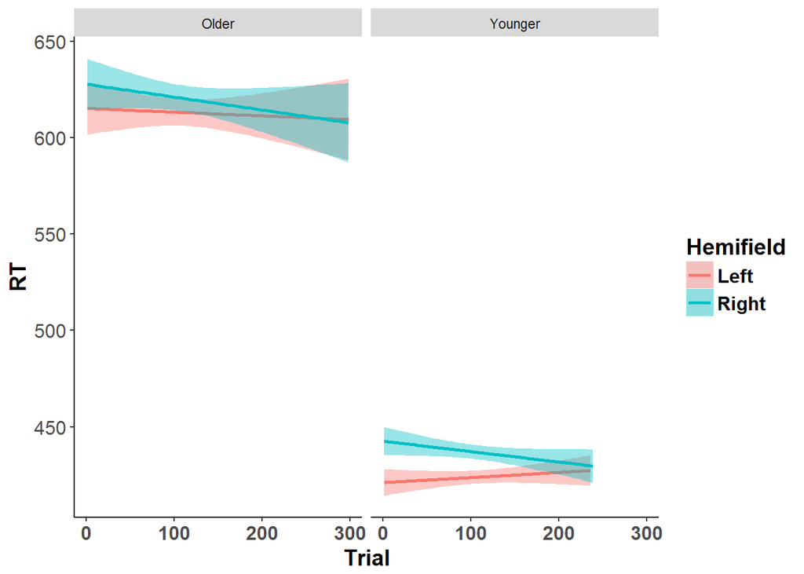

**So the linear mixed model approach ^ shows no significant Group x Hemifield effect**

## However simple effects of hemifield inside group linear mixed model approach confirms that Younger participants have signficantly faster RTs to left targets and Older participants do not:

```
##
##   Simultaneous Tests for General Linear Hypotheses
##
## Fit: lmer(formula = log(RT) ~ Hemifield + (Hemifield | ID) + (1 |
##     ITI) + (1 | Hemifield) + (1 | Trial), data = data2[data2$Group ==
##     "Older", ], REML = FALSE, na.action = na.omit)
##
## Linear Hypotheses:
##                     Estimate Std. Error z value      Pr(>|z|)
## (Intercept) == 0      6.3781     0.0491   130.0 <0.0000000001 ***
## HemifieldRight == 0   0.0123     0.0103     1.2          0.39
## ---
## Signif. codes:  0 '***' 0.001 '**' 0.01 '*' 0.05 '.' 0.1 ' ' 1
## (Adjusted p values reported -- single-step method)
```

```
##
##   Simultaneous Tests for General Linear Hypotheses
##
## Fit: lmer(formula = log(RT) ~ Hemifield + (Hemifield | ID) + (1 |
##     ITI) + (1 | Hemifield) + (1 | Trial), data = data2[data2$Group ==
##     "Younger", ], REML = FALSE, na.action = na.omit)
##
## Linear Hypotheses:
##                     Estimate Std. Error z value      Pr(>|z|)
## (Intercept) == 0     6.02469    0.04384  137.42 <0.0000000001 ***
## HemifieldRight == 0  0.02889    0.00837    3.45        0.0011 **
## ---
## Signif. codes:  0 '***' 0.001 '**' 0.01 '*' 0.05 '.' 0.1 ' ' 1
## (Adjusted p values reported -- single-step method)
```

### So Younger have significant pseudoneglect (i.e. faster RTs to left hemifield targets), and Older do not, but this is only seen in the simple effects (doing seperate test for each group). The factorial design gives no significant Group x Hemifield effect

**Nonetheless, lets plot this:**

```
## Automatically converting the following non-factors to factors: Group, Hemifield
```

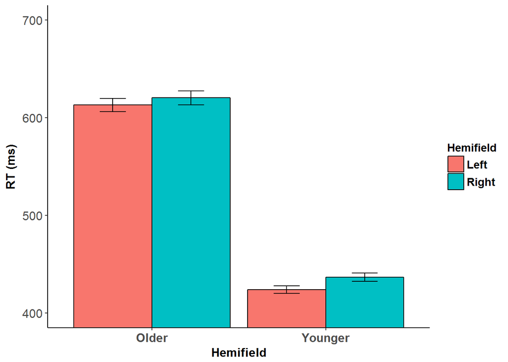

[output not shown]

### Next I’ll move on to look at the EEG data. This EEG data was low-pass filtered to 35Hz, and no high-pass filter applied. No CSD transformation was applied:

# Single trial N2 Amplitude

### N2c/i measurement window (100ms) was centred on peak amplitude of each INDIVIDUAL PARTICIANT’s AVERAGE N2c/i waveforms:

```
## [1] "Factorial Permutation test for the Hemifield*Hemisphere*Group on the N2:"
```

```
##                       Effect     p p<.05
## 1                      Group 0.062
## 2                  Hemifield 0.132
## 3                 Hemisphere 0.608
## 4            Group:Hemifield 0.000     *
## 5           Group:Hemisphere 0.739
## 6       Hemifield:Hemisphere 0.034     *
## 7 Group:Hemifield:Hemisphere 0.058
```

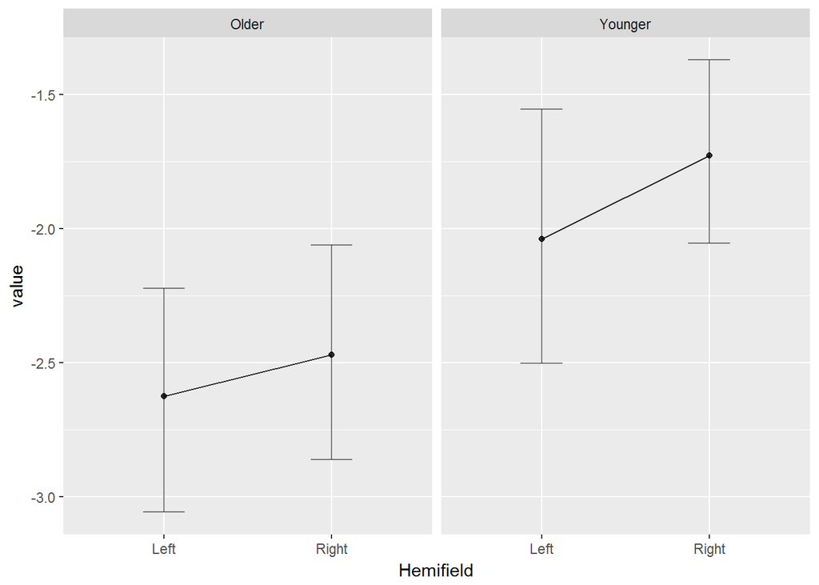

```
## [1] "Factorial Permutation test for the Hemifield*Group effect on N2c:"
```

```
##            Effect     p p<.05
## 1           Group 0.125
## 2       Hemifield 0.017     *
## 3 Group:Hemifield 0.108
```

```
## [1] "Factorial Permutation test for the Hemifield*Group effect on N2i:"
```

```
##            Effect     p p<.05
## 1           Group 0.081
## 2       Hemifield 0.349
## 3 Group:Hemifield 0.186
```

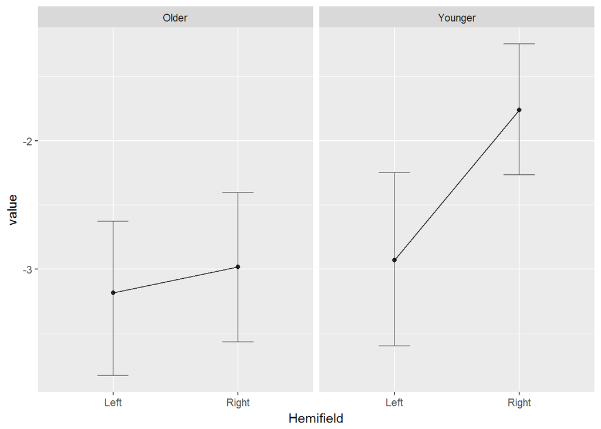

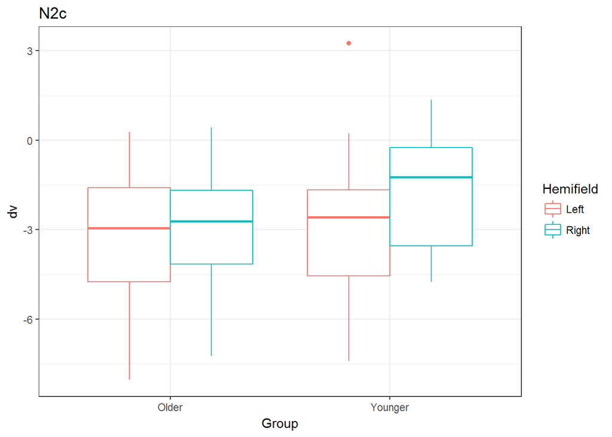

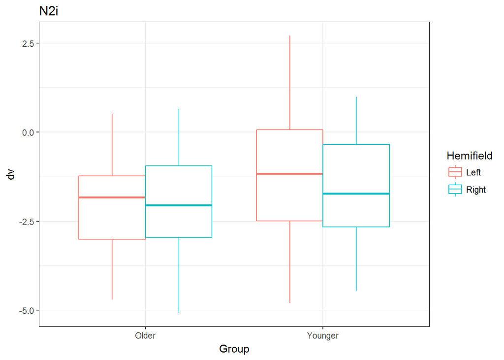

### Look at N2c/i peak latency

```
## [1] "Factorial Permutation test for the Hemifield*Group effect on N2c Latency:"
```

```
##            Effect     p p<.05
## 1           Group 0.001     *
## 2       Hemifield 0.007     *
## 3 Group:Hemifield 0.316
```

```
## [1] "Factorial Permutation test for the Hemifield*Group effect on N2i Latency:"
```

```
##            Effect     p p<.05
## 1           Group 0.332
## 2       Hemifield 0.336
## 3 Group:Hemifield 0.804
```

# CPP onset

## CPP onset was measured on a participant level (rather than on a single trial level) using the same method as Ger’s Current Biology paper. There is no significant Group x Hemifield effect unfortunately

```
## [1] ID        Group     Hemifield CPPonset
## <0 rows> (or 0-length row.names)
```

```
## $ANOVA
##            Effect DFn DFd      F          p p<.05      ges
## 2           Group   1  55 29.826 0.00000117     * 0.305553
## 3       Hemifield   1  55  0.432 0.51369230       0.001480
## 4 Group:Hemifield   1  55  0.173 0.67893726       0.000594
```

```
## [1] "Factorial Permutation test for the Hemifield*Group effect on CPPonset:"
```

```
##            Effect     p p<.05
## 1           Group 0.000     *
## 2       Hemifield 0.541
## 3 Group:Hemifield 0.704
```

```
## [1] "Factorial Permutation test for the Hemifield effect on CPPonset inside younger participants only:"
```

```
##      Effect     p p<.05
## 1 Hemifield 0.059
```

```
## [1] "Factorial Permutation test for the Hemifield effect on CPPonset inside Older participants only:"
```

```
##      Effect     p p<.05
## 1 Hemifield 0.933
```

**Lets plot this:**

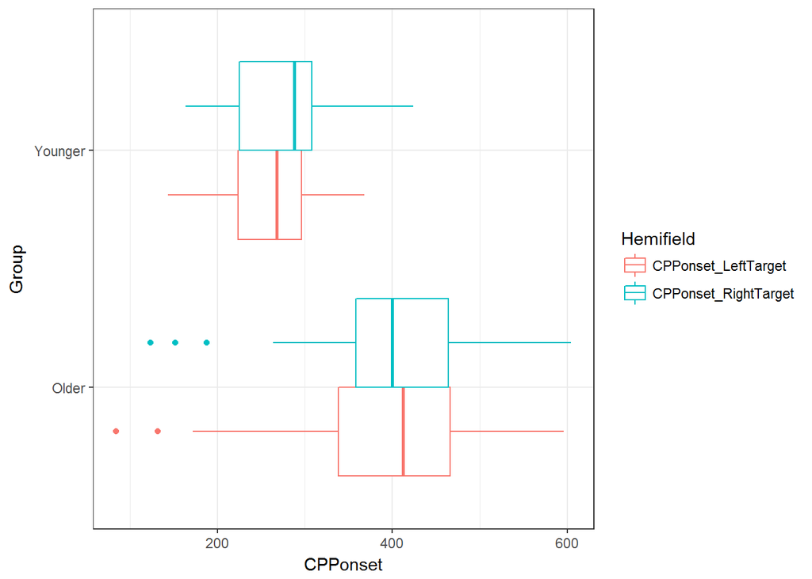

# Younger Participants have significantly steaper CPP slope analysis than Older participants, however

```
## [1] "Factorial Permutation test for the Hemifield*Group effect on CPPslope:"
```

```
##            Effect     p p<.05
## 1           Group 0.001     *
## 2       Hemifield 0.543
## 3 Group:Hemifield 0.509
```

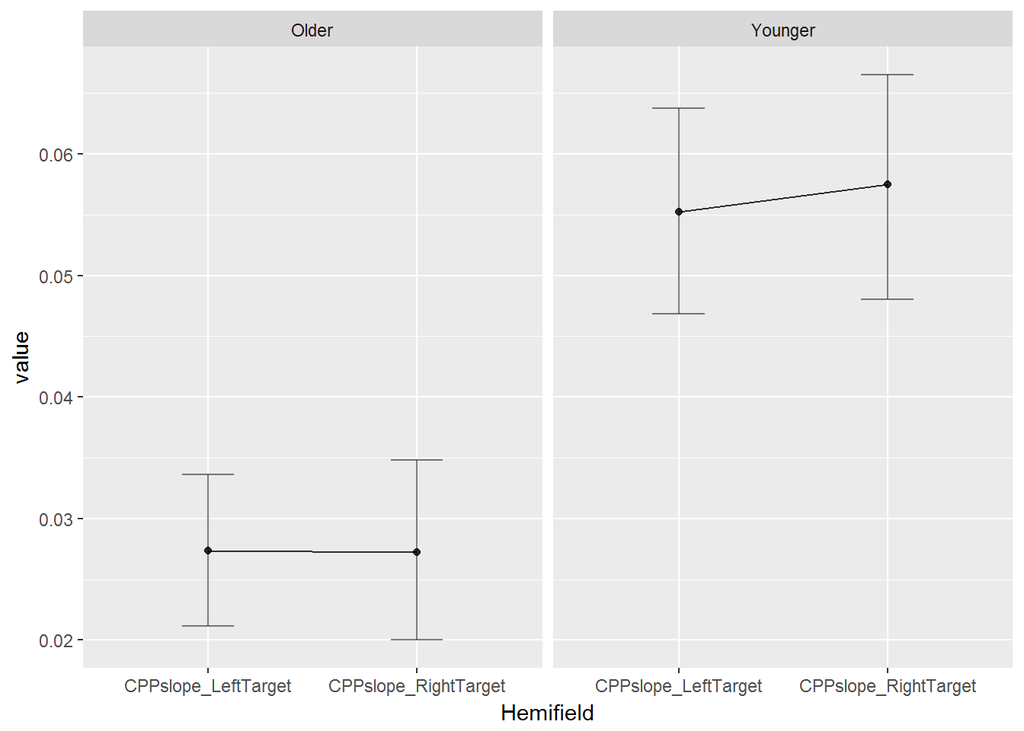

```
## [1] "Factorial Permutation test for the effect of Hemifield on CPPslope inside Younger group only:"
```

```
##      Effect     p p<.05
## 1 Hemifield 0.395
```

```
## [1] "Factorial Permutation test for the effect of Hemifield on CPPslope inside Older group only:"
```

```
##      Effect    p p<.05
## 1 Hemifield 0.96
```

# Look at multiple regression to predict RT_Asym

```
## Analysis of Variance Table
##
## Model  1: RT_Asym ~ 1
## Model  2: RT_Asym ~ Gender
## Model  3: RT_Asym ~ Gender + Group
## Model  4: RT_Asym ~ Gender + Group + N2c_Asym
## Model  5: RT_Asym ~ Gender + Group + N2c_Asym + N2c_latency_Asym
## Model  6: RT_Asym ~ Gender + Group + N2c_Asym + N2c_latency_Asym + CPPonset_Asym
## Model  7: RT_Asym ~ Gender + Group + N2c_Asym + N2c_latency_Asym + CPPonset_Asym +
##     CPPslope_Asym
## Model  8: RT_Asym ~ Gender + Group + N2c_Asym + N2c_latency_Asym + CPPonset_Asym +
##     CPPslope_Asym + Gender:Group
## Model  9: RT_Asym ~ Gender + Group + N2c_Asym + N2c_latency_Asym + CPPonset_Asym +
##     CPPslope_Asym + Gender:Group + Group:N2c_Asym
## Model 10: RT_Asym ~ Gender + Group + N2c_Asym + N2c_latency_Asym + CPPonset_Asym +
##     CPPslope_Asym + Gender:Group + Group:N2c_Asym + Group:N2c_latency_Asym
## Model 11: RT_Asym ~ Gender + Group + N2c_Asym + N2c_latency_Asym + CPPonset_Asym +
##     CPPslope_Asym + Gender:Group + Group:N2c_Asym + Group:N2c_latency_Asym +
##     Group:CPPonset_Asym
## Model 12: RT_Asym ~ Gender + Group + N2c_Asym + N2c_latency_Asym + CPPonset_Asym +
##     CPPslope_Asym + Gender:Group + Group:N2c_Asym + Group:N2c_latency_Asym +
##     Group:CPPonset_Asym + Group:CPPslope_Asym
##    Res.Df    RSS Df Sum of Sq    F Pr(>F)
## 1      56 0.0389
## 2      55 0.0347  1   0.00420 6.11  0.017 *
## 3      54 0.0337  1   0.00105 1.52  0.224
## 4      53 0.0335  1   0.00015 0.22  0.642
## 5      52 0.0331  1   0.00046 0.67  0.418
## 6      51 0.0331  1   0.00000 0.00  0.986
## 7      50 0.0326  1   0.00041 0.60  0.442
## 8      49 0.0326  1   0.00004 0.05  0.817
## 9      48 0.0317  1   0.00092 1.34  0.254
## 10     47 0.0317  1   0.00000 0.00  0.985
## 11     46 0.0309  1   0.00076 1.10  0.300
## 12     45 0.0309  1   0.00000 0.00  0.959
## ---
## Signif. codes:  0 '***' 0.001 '**' 0.01 '*' 0.05 '.' 0.1 ' ' 1
```

```
##
## Call:
## lm(formula = RT_Asym ~ Gender, data = participant_level)
##
## Residuals:
##      Min       1Q   Median       3Q      Max
## -0.04900 -0.01750 -0.00265  0.01952  0.05203
##
## Coefficients:
##             Estimate Std. Error t value Pr(>|t|)
## (Intercept) -0.00357    0.00451   -0.79    0.432
## GenderM     -0.01724    0.00668   -2.58    0.013 *
## ---
## Signif. codes:  0 '***' 0.001 '**' 0.01 '*' 0.05 '.' 0.1 ' ' 1
##
## Residual standard error: 0.0251 on 55 degrees of freedom
## Multiple R-squared:  0.108,  Adjusted R-squared:  0.0918
## F-statistic: 6.66 on 1 and 55 DF,  p-value: 0.0126
```

```
##
## Call:
## lm(formula = RT_Asym ~ Gender + Group, data = participant_level)
##
## Residuals:
##      Min       1Q   Median       3Q      Max
## -0.04512 -0.01763 -0.00062  0.02140  0.04774
##
## Coefficients:
##              Estimate Std. Error t value Pr(>|t|)
## (Intercept)   0.00114    0.00577    0.20     0.84
## GenderM      -0.01766    0.00665   -2.66     0.01 *
## GroupYounger -0.00859    0.00663   -1.30     0.20
## ---
## Signif. codes:  0 '***' 0.001 '**' 0.01 '*' 0.05 '.' 0.1 ' ' 1
##
## Residual standard error: 0.025 on 54 degrees of freedom
## Multiple R-squared:  0.135,  Adjusted R-squared:  0.103
## F-statistic: 4.21 on 2 and 54 DF,  p-value: 0.02
```

```
##
## Call:
## lm(formula = RT_Asym ~ Gender + Group + N2c_Asym, data = participant_level)
##
## Residuals:
##      Min       1Q   Median       3Q      Max
## -0.04440 -0.01718 -0.00022  0.02151  0.04736
##
## Coefficients:
##              Estimate Std. Error t value Pr(>|t|)
## (Intercept)   0.00128    0.00582    0.22    0.827
## GenderM      -0.01756    0.00670   -2.62    0.011 *
## GroupYounger -0.00833    0.00670   -1.24    0.220
## N2c_Asym     -0.00216    0.00441   -0.49    0.627
## ---
## Signif. codes:  0 '***' 0.001 '**' 0.01 '*' 0.05 '.' 0.1 ' ' 1
##
## Residual standard error: 0.0251 on 53 degrees of freedom
## Multiple R-squared:  0.139,  Adjusted R-squared:  0.09
## F-statistic: 2.85 on 3 and 53 DF,  p-value: 0.0462
```

```
##
## Call:
## lm(formula = RT_Asym ~ Gender + Group + N2c_Asym + N2c_latency_Asym,
##     data = participant_level)
##
## Residuals:
##      Min       1Q   Median       3Q      Max
## -0.04436 -0.01494 -0.00282  0.02194  0.04859
##
## Coefficients:
##                   Estimate Std. Error t value Pr(>|t|)
## (Intercept)       0.000883   0.005856    0.15   0.8807
## GenderM          -0.018098   0.006746   -2.68   0.0098 **
## GroupYounger     -0.008996   0.006765   -1.33   0.1894
## N2c_Asym         -0.002478   0.004442   -0.56   0.5794
## N2c_latency_Asym -0.022025   0.025902   -0.85   0.3990
## ---
## Signif. codes:  0 '***' 0.001 '**' 0.01 '*' 0.05 '.' 0.1 ' ' 1
##
## Residual standard error: 0.0252 on 52 degrees of freedom
## Multiple R-squared:  0.151,  Adjusted R-squared:  0.0852
## F-statistic:  2.3 on 4 and 52 DF,  p-value: 0.0706
```

```
##
## Call:
## lm(formula = RT_Asym ~ Gender + Group + N2c_Asym + N2c_latency_Asym +
##     CPPonset_Asym, data = participant_level)
##
## Residuals:
##      Min       1Q   Median       3Q      Max
## -0.04437 -0.01492 -0.00282  0.02190  0.04862
##
## Coefficients:
##                   Estimate Std. Error t value Pr(>|t|)
## (Intercept)       0.000881   0.005914    0.15    0.882
## GenderM          -0.018112   0.006852   -2.64    0.011 *
## GroupYounger     -0.008998   0.006832   -1.32    0.194
## N2c_Asym         -0.002482   0.004492   -0.55    0.583
## N2c_latency_Asym -0.022048   0.026182   -0.84    0.404
## CPPonset_Asym    -0.000460   0.024438   -0.02    0.985
## ---
## Signif. codes:  0 '***' 0.001 '**' 0.01 '*' 0.05 '.' 0.1 ' ' 1
##
## Residual standard error: 0.0255 on 51 degrees of freedom
## Multiple R-squared:  0.151,  Adjusted R-squared:  0.0673
## F-statistic: 1.81 on 5 and 51 DF,  p-value: 0.128
```

```
##
## Call:
## lm(formula = RT_Asym ~ Gender + Group + N2c_Asym + N2c_latency_Asym +
##     CPPonset_Asym + CPPslope_Asym, data = participant_level)
##
## Residuals:
##     Min      1Q  Median      3Q     Max
## -0.0453 -0.0159 -0.0031  0.0224  0.0486
##
## Coefficients:
##                   Estimate Std. Error t value Pr(>|t|)
## (Intercept)      -0.000290   0.006114   -0.05    0.962
## GenderM          -0.017548   0.006913   -2.54    0.014 *
## GroupYounger     -0.008525   0.006882   -1.24    0.221
## N2c_Asym         -0.002939   0.004545   -0.65    0.521
## N2c_latency_Asym -0.027151   0.027046   -1.00    0.320
## CPPonset_Asym     0.000792   0.024577    0.03    0.974
## CPPslope_Asym    -0.005493   0.006899   -0.80    0.430
## ---
## Signif. codes:  0 '***' 0.001 '**' 0.01 '*' 0.05 '.' 0.1 ' ' 1
##
## Residual standard error: 0.0256 on 50 degrees of freedom
## Multiple R-squared:  0.161,  Adjusted R-squared:  0.0605
## F-statistic:  1.6 on 6 and 50 DF,  p-value: 0.166
```

# Look at logistic regression to predict Group (Older vs Younger)

| term | estimate | std.error | statistic | p.value |
| --- | --- | --- | --- | --- |
| (Intercept) | -0.102 | 0.328 | -0.312 | 0.755 |
| RT_Asym | -11.088 | 10.633 | -1.043 | 0.297 |
| CPPonset_Asym | -0.123 | 1.944 | -0.064 | 0.949 |
| N2c_latency_Asym | -1.660 | 2.182 | -0.761 | 0.447 |
| N2c_Asym | 0.172 | 0.365 | 0.472 | 0.637 |
| CPPslope_Asym | 0.253 | 0.591 | 0.428 | 0.669 |

```
## [1] 2.56
```

```
## [1] 5
```

```
## [1] 0.768
```

```
## Pseudo R^2 for logistic regression
## Hosmer and Lemeshow R^2   0.032
## Cox and Snell R^2         0.044
## Nagelkerke R^2            0.059
```

```
##      (Intercept)          RT_Asym    CPPonset_Asym N2c_latency_Asym
##        0.9026909        0.0000153        0.8838763        0.1900923
##         N2c_Asym    CPPslope_Asym
##        1.1877217        1.2879220
```

```
##                                2.5 %   97.5 %
## (Intercept)      0.46611257571256337     1.71
## RT_Asym          0.00000000000000628 12855.55
## CPPonset_Asym    0.01404345379311615    50.40
## N2c_latency_Asym 0.00221992742542979    13.25
## N2c_Asym         0.56787794256002577     2.63
## CPPslope_Asym    0.42336759787431977     5.25
```

```
## Wald test:
## ----------
##
## Chi-squared test:
## X2 = 1.9, df = 4, P(> X2) = 0.75
```

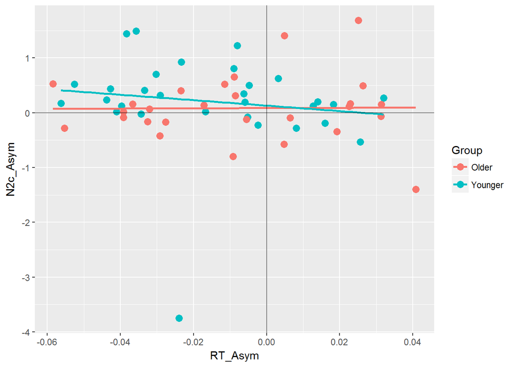

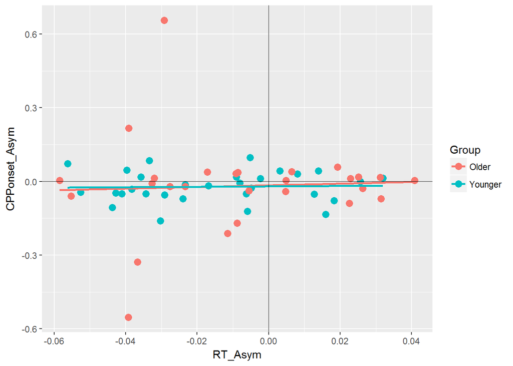

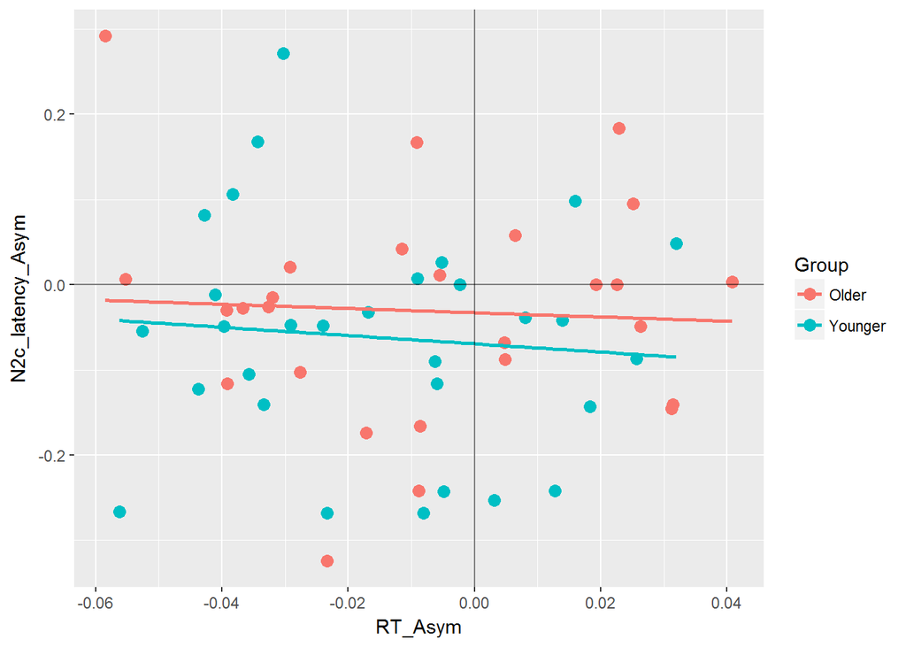

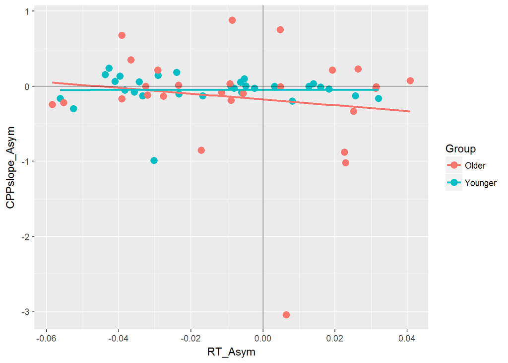

# Load Stim_locked_ERP data

# plots - No CSD transform

```
## Automatically converting the following non-factors to factors: Time, Hemifield
```

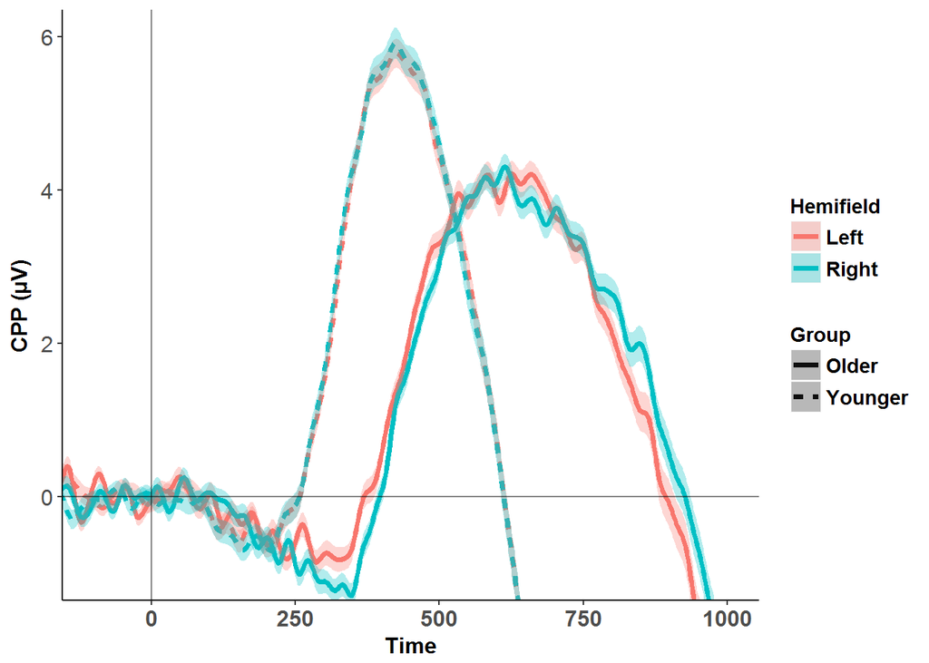

```
## Automatically converting the following non-factors to factors: Time, Hemifield
```

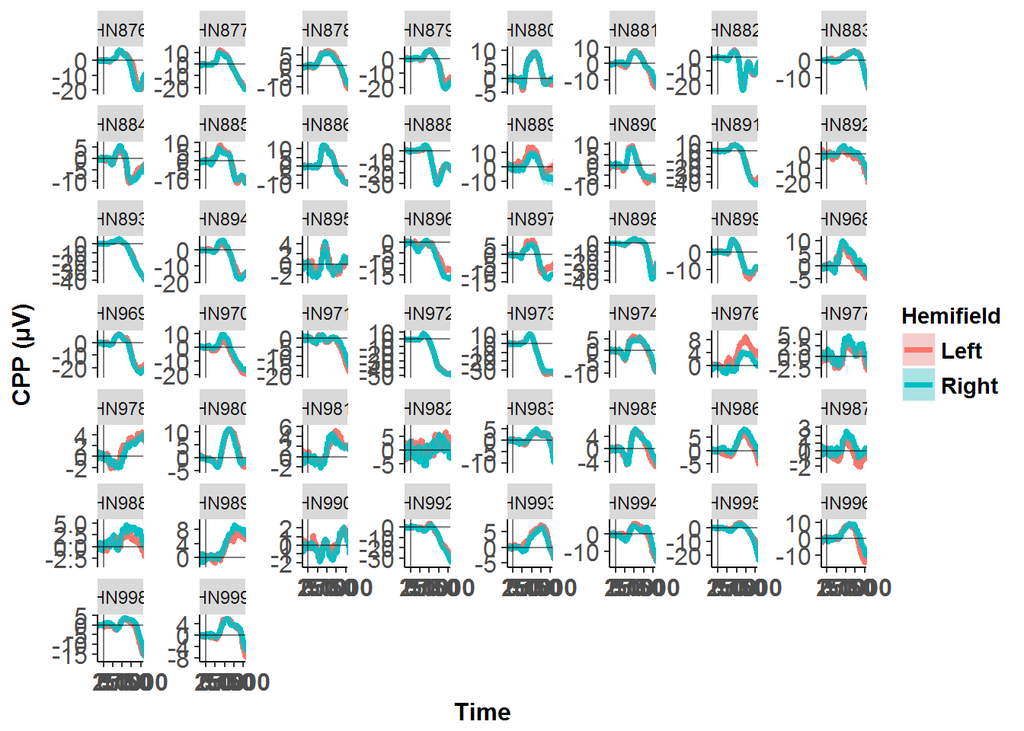

```
## Automatically converting the following non-factors to factors: Time, Hemifield
```

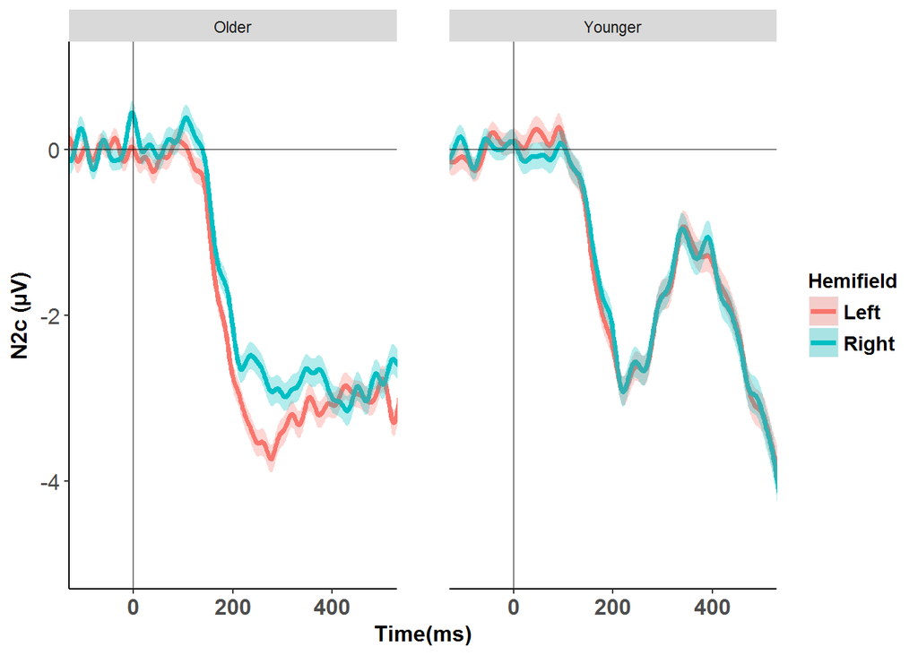

```
## Automatically converting the following non-factors to factors: Time, Hemifield
```

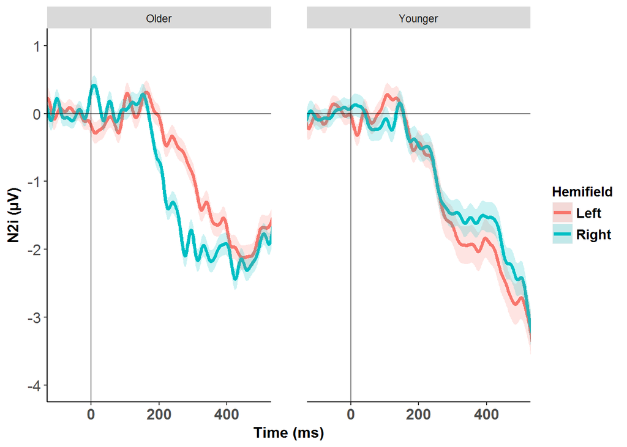

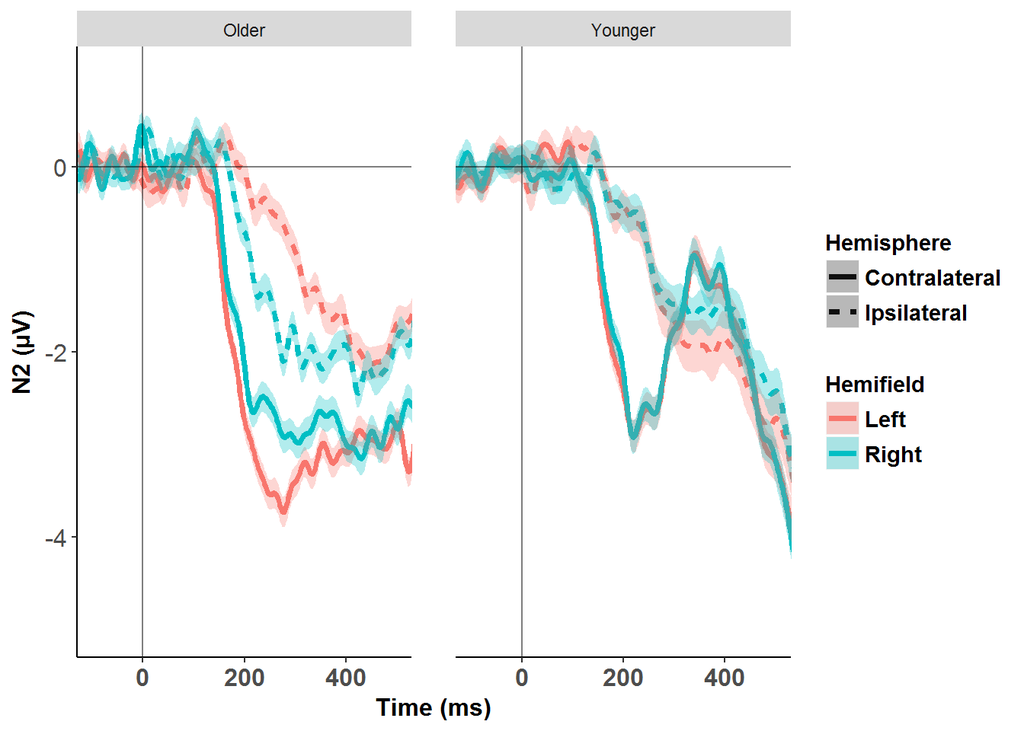

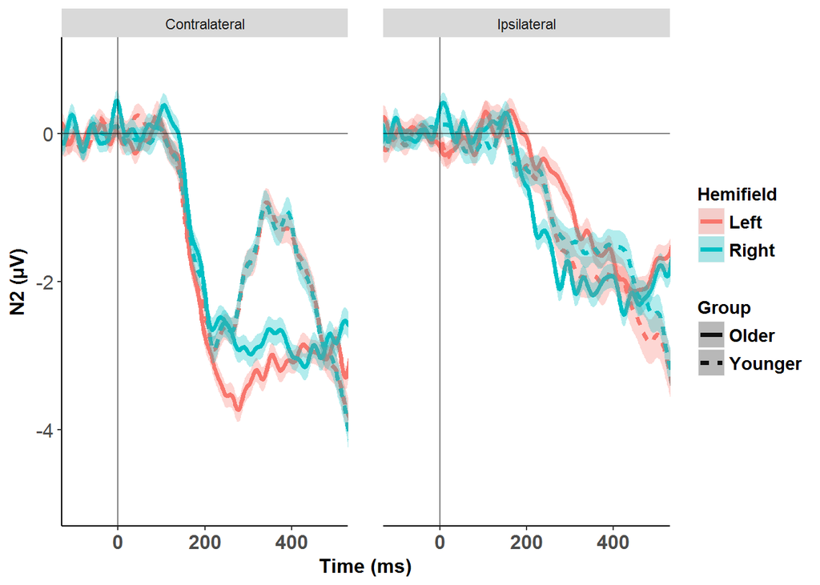

# CSD transform applied:

```
## Automatically converting the following non-factors to factors: Time, Hemifield
```

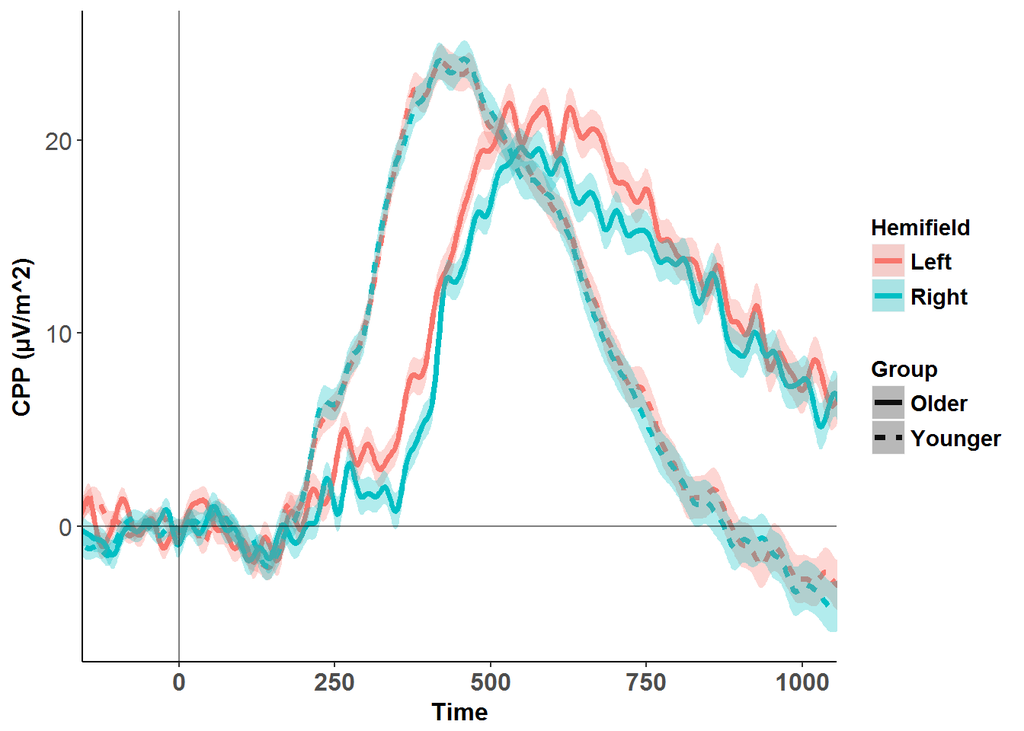

```r
#CPP

source("summarySEwithin.R")
data_Stim_locked_ERP %>%
    filter(!FixationBreak & !Art_neg100_100PR & Accuracy=="Hit") %>%
    summarySEwithin(., measurevar="CPP_CSD",
                      betweenvars=c("Group"),
                      withinvars=c("Time", "Hemifield"),
                      idvar="ID") %>%
    mutate(Time = as.numeric(as.character(Time))) %>%
    ggplot(., aes(x=Time, y=CPP_CSD, color=Hemifield,fill=Hemifield, linetype=Group)) +
    geom_line(size=1.4) + geom_ribbon(aes(ymin=CPP_CSD-se, ymax=CPP_CSD+se), alpha = 0.3, colour=NA) +
        geom_hline(yintercept=0, alpha = 0.5) + geom_vline(xintercept=0, alpha = 0.5) +
    coord_cartesian(xlim = c(-100, 1000)) +
    xlab("Time") + ylab("CPP (\u00b5V/m^2)") +
    theme(axis.title.x = element_text(face="bold", size=12),
          axis.text.x  = element_text(face="bold", angle=0,  size=12)) +
    theme(axis.title.y = element_text(face="bold", size=12),
          axis.text.y  = element_text(angle=0, vjust=0.5, size=12)) +
    theme(legend.title = element_text(size=11, face="bold")) +
    theme(legend.text = element_text(size = 11, face = "bold")) +
    theme(panel.grid.major = element_blank(), panel.grid.minor = element_blank(),
          panel.background = element_blank(), axis.line = element_line(colour = "black"))
```

```r
# source("summarySEwithin.R")
# data_Stim_locked_ERP %>%
#     filter(!FixationBreak & !Art_neg100_100PR & Accuracy=="Hit") %>%
#     summarySEwithin(., measurevar="CPP_CSD",
#                       betweenvars=c("ID"),
#                       withinvars=c("Time", "Hemifield"),
#                       idvar=NULL) %>%
#     mutate(Time = as.numeric(as.character(Time))) %>%
#     ggplot(., aes(x=Time, y=CPP_CSD, color=Hemifield,fill=Hemifield)) +
#     geom_line(size=1.4) + geom_ribbon(aes(ymin=CPP_CSD-se, ymax=CPP_CSD+se), alpha = 0.3, colour=NA) +
#         geom_hline(yintercept=0, alpha = 0.5) + geom_vline(xintercept=0, alpha = 0.5) +
#     coord_cartesian(xlim = c(-100, 1000)) +
#     xlab("Time") + ylab("CPP (\u00b5V/m^2)") +
#     theme(axis.title.x = element_text(face="bold", size=12),
#           axis.text.x  = element_text(face="bold", angle=0,  size=12)) +
#     theme(axis.title.y = element_text(face="bold", size=12),
#           axis.text.y  = element_text(angle=0, vjust=0.5, size=12)) +
#     theme(legend.title = element_text(size=11, face="bold")) +
#     theme(legend.text = element_text(size = 11, face = "bold")) +
#     theme(panel.grid.major = element_blank(), panel.grid.minor = element_blank(),
#           panel.background = element_blank(), axis.line = element_line(colour = "black")) +
#     facet_wrap(~ ID, scales="free_y")
# ggsave("CPP_AllParticipants.png")


##################################################################################################


#N2c

plotdata_N2c_CSD <-  data_Stim_locked_ERP %>%
    filter(!FixationBreak & !Art_neg100_100PR & Accuracy=="Hit") %>%
    summarySEwithin(.,
                      measurevar="N2c_CSD",
                      betweenvars=c("Group"),
                      withinvars=c("Time", "Hemifield"),
                      idvar="ID") %>%
    mutate(Time = as.numeric(as.character(Time)))
```

```
## Automatically converting the following non-factors to factors: Time, Hemifield
```

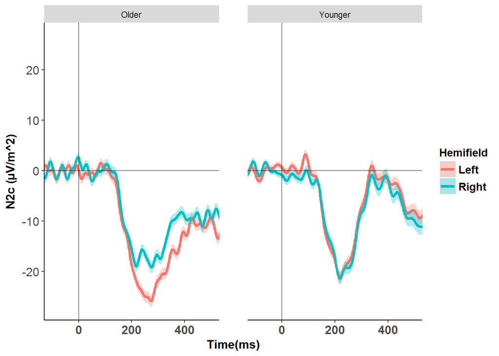

```r
ggplot(plotdata_N2c_CSD, aes(x=Time, y=N2c_CSD, color=Hemifield,fill=Hemifield)) + geom_line(size=1.4) +
    geom_ribbon(aes(ymin=N2c_CSD-se, ymax=N2c_CSD+se), alpha = 0.3, colour=NA) +
    geom_hline(yintercept=0, alpha = 0.5) + geom_vline(xintercept=0, alpha = 0.5) +
    coord_cartesian( xlim = c(-100, 500)) +
    xlab("Time(ms)") + ylab("N2c (\u00b5V/m^2)") +
    theme(axis.title.x = element_text(face="bold", size=12),
          axis.text.x  = element_text(face="bold", angle=0,  size=12)) +
    theme(axis.title.y = element_text(face="bold", size=12),
          axis.text.y  = element_text(angle=0, vjust=0.5, size=12)) +
    theme(legend.title = element_text(size=11, face="bold")) +
    theme(legend.text = element_text(size = 11, face = "bold")) +
    theme(panel.grid.major = element_blank(), panel.grid.minor = element_blank(),
          panel.background = element_blank(), axis.line = element_line(colour = "black")) + facet_wrap(~ Group) +
    theme(panel.margin = unit(2, "lines"))
```

```r
#N2i_CSD
plotdata_N2i_CSD <-  data_Stim_locked_ERP %>%
    filter(!FixationBreak & !Art_neg100_100PR & Accuracy=="Hit") %>%
    summarySEwithin(.,
                      measurevar="N2i_CSD",
                      betweenvars=c("Group"),
                      withinvars=c("Time", "Hemifield"),
                      idvar="ID") %>%
    mutate(Time = as.numeric(as.character(Time)))
```

```
## Automatically converting the following non-factors to factors: Time, Hemifield
```

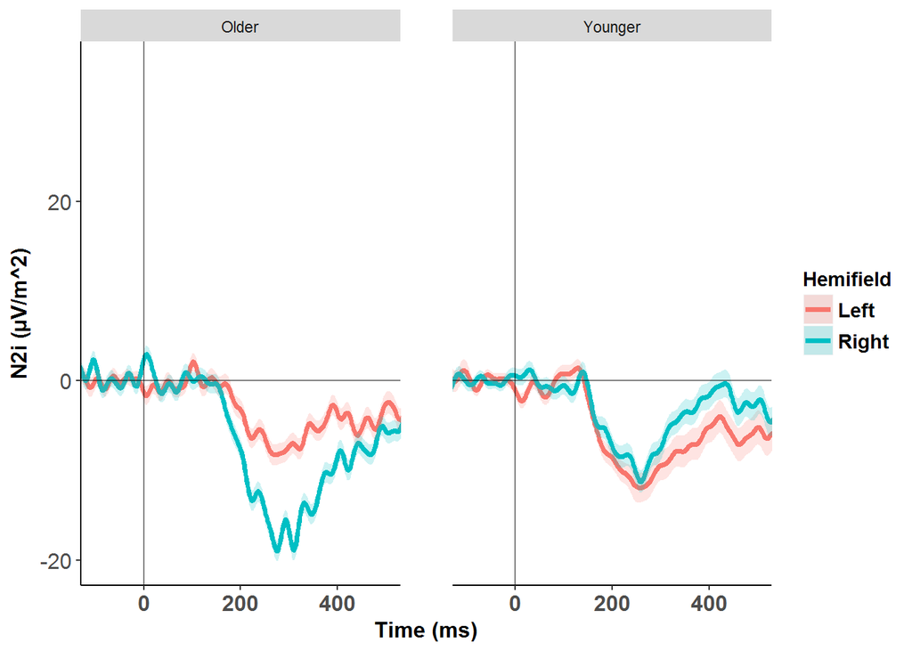

```r
ggplot(plotdata_N2i_CSD, aes(x=Time, y=N2i_CSD, color=Hemifield,fill=Hemifield)) + geom_line(size=1.4) +
    geom_ribbon(aes(ymin=N2i_CSD-se, ymax=N2i_CSD+se), alpha = 0.2, colour=NA) +
        geom_hline(yintercept=0, alpha = 0.5) + geom_vline(xintercept=0, alpha = 0.5) +
    coord_cartesian(xlim = c(-100, 500)) +
    xlab("Time (ms)") + ylab("N2i (\u00b5V/m^2)") +
    theme(axis.title.x = element_text(face="bold", size=12),
          axis.text.x  = element_text(face="bold", angle=0,  size=12)) +
    theme(axis.title.y = element_text(face="bold", size=12),
          axis.text.y  = element_text(angle=0, vjust=0.5, size=12)) +
    theme(legend.title = element_text(size=11, face="bold")) +
    theme(legend.text = element_text(size = 11, face = "bold")) +
    theme(panel.grid.major = element_blank(), panel.grid.minor = element_blank(),
          panel.background = element_blank(), axis.line = element_line(colour = "black")) + facet_wrap(~ Group) +
    theme(panel.margin = unit(2, "lines"))
```

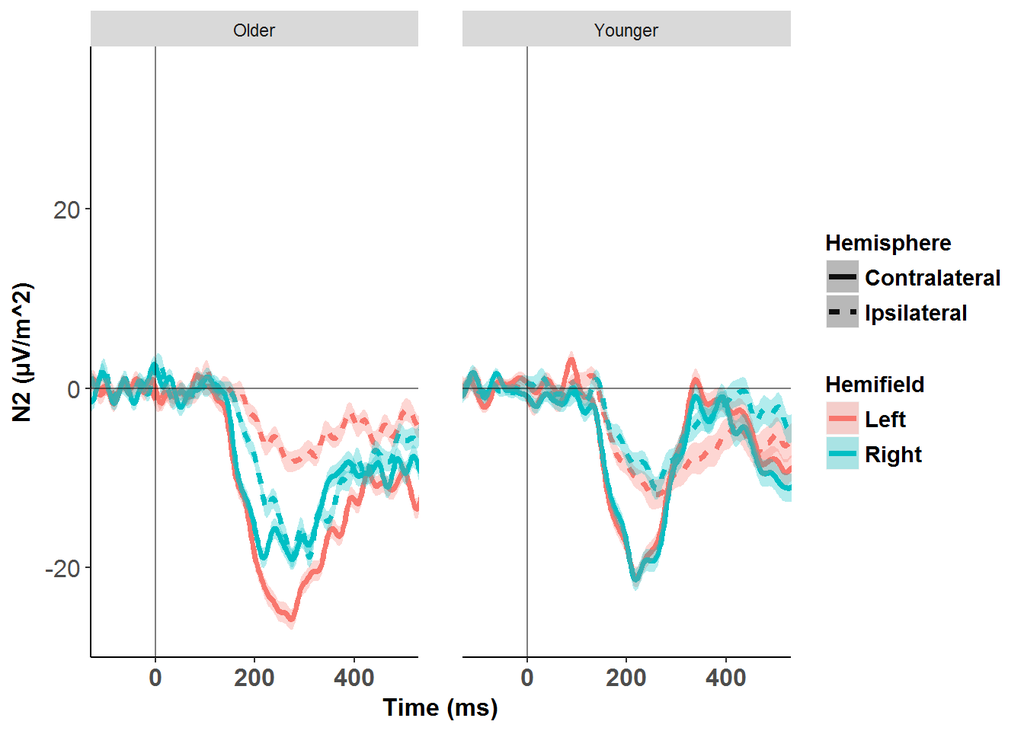

```r
###################Plot N2c_CSD and N2i_CSD trace in the same plot #####################
plotdata_N2i_CSD$Hemisphere<-rep("Ipsilateral",length(plotdata_N2i_CSD[,1]))
names(plotdata_N2i_CSD)[names(plotdata_N2i_CSD)=="N2i_CSD"] <- "N2"
names(plotdata_N2i_CSD)[names(plotdata_N2i_CSD)=="N2i_CSD_norm"] <- "N2_norm"

plotdata_N2c_CSD$Hemisphere<-rep("Contralateral",length(plotdata_N2c_CSD[,1]))
names(plotdata_N2c_CSD)[names(plotdata_N2c_CSD)=="N2c_CSD"] <- "N2"
names(plotdata_N2c_CSD)[names(plotdata_N2c_CSD)=="N2c_CSD_norm"] <- "N2_norm"
plotdata_N2<-rbind(plotdata_N2i_CSD,plotdata_N2c_CSD)


#facet_wrap(~ Group)
ggplot(plotdata_N2, aes(x=Time, y=N2, color=Hemifield,fill=Hemifield, linetype=Hemisphere)) +
    geom_line(size=1.4) + geom_ribbon(aes(ymin=N2-se, ymax=N2+se), alpha = 0.3, colour=NA) +
        geom_hline(yintercept=0, alpha = 0.5) + geom_vline(xintercept=0, alpha = 0.5) +
    coord_cartesian(xlim = c(-100, 500)) +
    xlab("Time (ms)") + ylab("N2 (\u00b5V/m^2)") +
    theme(axis.title.x = element_text(face="bold", size=12),
          axis.text.x  = element_text(face="bold", angle=0,  size=12)) +
    theme(axis.title.y = element_text(face="bold", size=12),
          axis.text.y  = element_text(angle=0, vjust=0.5, size=12)) +
    theme(legend.title = element_text(size=11, face="bold")) +
    theme(legend.text = element_text(size = 11, face = "bold")) +
    theme(panel.grid.major = element_blank(), panel.grid.minor = element_blank(),
          panel.background = element_blank(), axis.line = element_line(colour = "black")) + facet_wrap(~ Group) +
    theme(panel.margin = unit(1.5, "lines"))
```

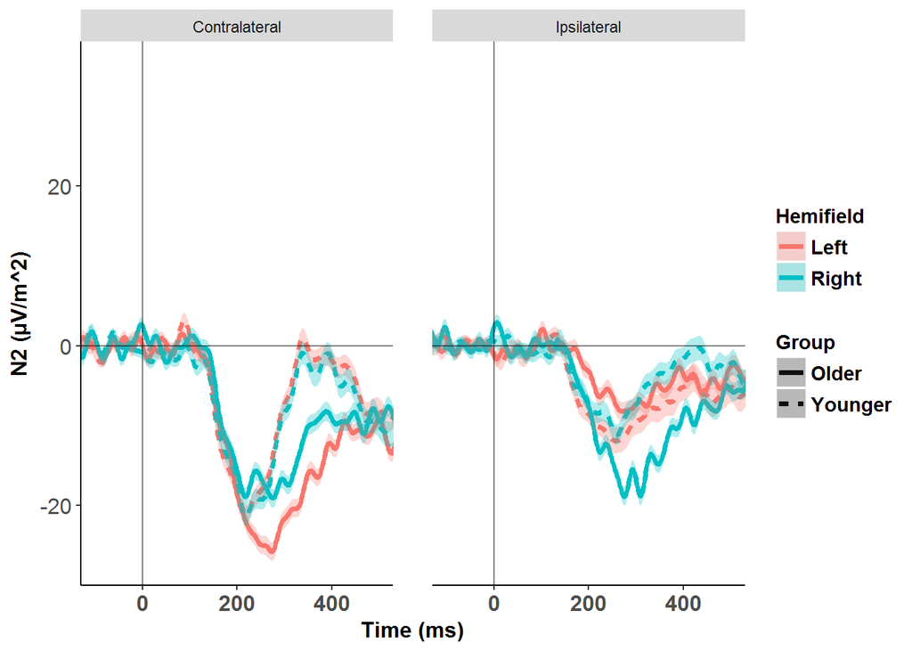

```r
# save(StimLockedN2_Plot_Group, file="StimLockedN2_Plot_Group.gg")


#  facet_wrap(~ Hemisphere)
ggplot(plotdata_N2, aes(x=Time, y=N2, color=Hemifield,fill=Hemifield, linetype=Group)) +
    geom_line(size=1.4) + geom_ribbon(aes(ymin=N2-se, ymax=N2+se), alpha = 0.3, colour=NA) +
        geom_hline(yintercept=0, alpha = 0.5) + geom_vline(xintercept=0, alpha = 0.5) +
    coord_cartesian(xlim = c(-100, 500)) +
    xlab("Time (ms)") + ylab("N2 (\u00b5V/m^2)") +
    theme(axis.title.x = element_text(face="bold", size=12),
          axis.text.x  = element_text(face="bold", angle=0,  size=12)) +
    theme(axis.title.y = element_text(face="bold", size=12),
          axis.text.y  = element_text(angle=0, vjust=0.5, size=12)) +
    theme(legend.title = element_text(size=11, face="bold")) +
    theme(legend.text = element_text(size = 11, face = "bold")) +
    theme(panel.grid.major = element_blank(), panel.grid.minor = element_blank(),
          panel.background = element_blank(), axis.line = element_line(colour = "black")) + facet_wrap(~ Hemisphere) +
    theme(panel.margin = unit(1.5, "lines"))
```

```r
# save(StimLockedN2_Plot_Hemisphere, file="StimLockedN2_Plot_Hemisphere.gg")


#N2c_CSD
plotdata_N2c_CSD <-  data_Stim_locked_ERP %>%
    filter(!FixationBreak & !Art_neg100_100PR & Accuracy=="Hit") %>%
    summarySEwithin(.,
                      measurevar="N2c_CSD",
                      betweenvars=c("ID"),
                      withinvars=c("Time", "Hemifield"),
                      idvar=NULL) %>%
    mutate(Time = as.numeric(as.character(Time)))
```

```
## Automatically converting the following non-factors to factors: Time, Hemifield
```

```r
# ggplot(plotdata_N2c_CSD, aes(x=Time, y=N2c_CSD, color=Hemifield,fill=Hemifield)) + geom_line(size=1.4) +
#     geom_ribbon(aes(ymin=N2c_CSD-se, ymax=N2c_CSD+se), alpha = 0.3, colour=NA) +
#     geom_hline(yintercept=0, alpha = 0.5) + geom_vline(xintercept=0, alpha = 0.5) +
#     coord_cartesian( xlim = c(-100, 500)) +
#     xlab("Time(ms)") + ylab("N2c (\u00b5V/m^2)") +
#     theme(axis.title.x = element_text(face="bold", size=12),
#           axis.text.x  = element_text(face="bold", angle=0,  size=12)) +
#     theme(axis.title.y = element_text(face="bold", size=12),
#           axis.text.y  = element_text(angle=0, vjust=0.5, size=12)) +
#     theme(legend.title = element_text(size=11, face="bold")) +
#     theme(legend.text = element_text(size = 11, face = "bold")) +
#     theme(panel.grid.major = element_blank(), panel.grid.minor = element_blank(),
#           panel.background = element_blank(), axis.line = element_line(colour = "black")) +
#     theme(panel.margin = unit(2, "lines")) +
#     facet_wrap(~ ID, scales="free_y")
# ggsave("N2c_AllParticipants.png")


#N2i_CSD
plotdata_N2i_CSD <-  data_Stim_locked_ERP %>%
    filter(!FixationBreak & !Art_neg100_100PR & Accuracy=="Hit") %>%
    summarySEwithin(.,
                      measurevar="N2i_CSD",
                      betweenvars=c("ID"),
                      withinvars=c("Time", "Hemifield"),
                      idvar=NULL) %>%
    mutate(Time = as.numeric(as.character(Time)))
```

```
## Automatically converting the following non-factors to factors: Time, Hemifield
```

```r
#
# p1<-ggplot(plotdata_N2i_CSD, aes(x=Time, y=N2i_CSD, color=Hemifield,fill=Hemifield)) + geom_line(size=1.4) +
#     geom_ribbon(aes(ymin=N2i_CSD-se, ymax=N2i_CSD+se), alpha = 0.2, colour=NA) +
#         geom_hline(yintercept=0, alpha = 0.5, size=1.4) +
#     geom_vline(xintercept=0, alpha = 0.5, size=1.4) +
#     coord_cartesian(xlim = c(-100, 500)) +
#     xlab("Time (ms)") + ylab("N2i (\u00b5V/m^2)") +
#     theme(axis.title.x = element_text(face="bold", size=12),
#           axis.text.x  = element_text(face="bold", angle=0,  size=12),
#           axis.title.y = element_text(face="bold", size=12),
#           axis.text.y  = element_text(angle=0, vjust=0.5, size=12),
#           legend.title = element_text(size=11, face="bold"),
#           legend.text = element_text(size = 11, face = "bold"),
#           panel.grid.major = element_blank(),
#           panel.grid.minor = element_blank(),
#           panel.background = element_blank(),
#           axis.line = element_line(colour = "black"),
#           panel.margin = unit(2, "lines")) +
#     facet_wrap(~ ID, scales="free_y")
# ggsave("N2i_AllParticipants.png")
#
#
```

## Resp-locked CPP

```
## Automatically converting the following non-factors to factors: Time, Hemifield
```

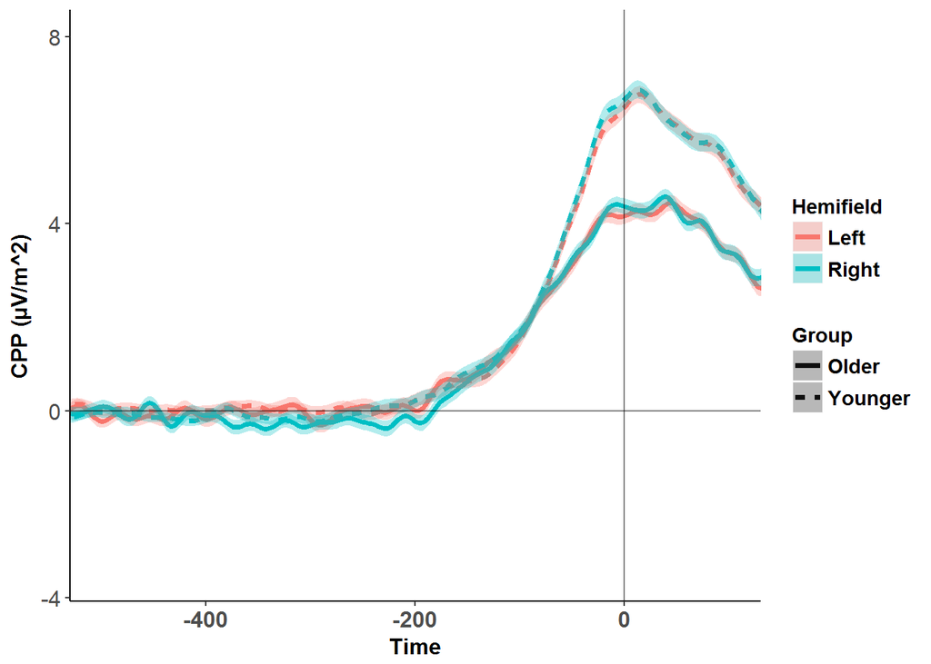

```r
data_Resp_locked_ERP <- read.csv("S:/R-MNHS-SPP/Bellgrove-data/11.Megan_ONeill/Analysis Scripts_Matlab/master_matrix_R_Resp_locked_ERP_Healthy.csv", header=FALSE)


data_Resp_locked_ERP<- data_Resp_locked_ERP %>% #Rename data columns:
    rename(.,
            ID_num=V1,
           Group=V2,
           TotalTrialNumber=V3,
           Trial=V4,
           PupilDiameter=V5,
           CPP=V6,
           TargetSide=V7,
           N2c=V8,
           N2i=V9,
           Time=V10,
           CPP_CSD=V11,
           N2c_CSD=V12,
           N2i_CSD=V13) %>%
    left_join(., to_merge, by=c("ID_num", "Trial")) %>%
    mutate(Group= ifelse(Group==1, "Younger", "Older"))  %>% #next make the required columns into factors:
    mutate_each_(funs(factor), c("Group", "ID")) %>%#next Order any ordinal factors
    mutate(ITI= ordered(ITI))  %>%
    filter(!RejectedTrial & RT<1500 & RT>200)


#CPP

source("summarySEwithin.R")
data_Resp_locked_ERP %>%
    filter(!FixationBreak & !Art_neg100_100PR & Accuracy=="Hit") %>%
    summarySEwithin(., measurevar="CPP",
                      betweenvars=c("Group"),
                      withinvars=c("Time", "Hemifield"),
                      idvar="ID") %>%
    mutate(Time = as.numeric(as.character(Time))) %>%
    ggplot(., aes(x=Time, y=CPP, color=Hemifield,fill=Hemifield, linetype=Group)) +
    geom_line(size=1.4) + geom_ribbon(aes(ymin=CPP-se, ymax=CPP+se), alpha = 0.3, colour=NA) +
        geom_hline(yintercept=0, alpha = 0.5) + geom_vline(xintercept=0, alpha = 0.5) +
    coord_cartesian(ylim = c(-3.5, 8),  xlim = c(-500, 100)) +
    xlab("Time") + ylab("CPP (\u00b5V/m^2)") +
    theme(axis.title.x = element_text(face="bold", size=12),
          axis.text.x  = element_text(face="bold", angle=0,  size=12)) +
    theme(axis.title.y = element_text(face="bold", size=12),
          axis.text.y  = element_text(angle=0, vjust=0.5, size=12)) +
    theme(legend.title = element_text(size=11, face="bold")) +
    theme(legend.text = element_text(size = 11, face = "bold")) +
    theme(panel.grid.major = element_blank(), panel.grid.minor = element_blank(),
          panel.background = element_blank(), axis.line = element_line(colour = "black"))
```

```r
# source("summarySEwithin.R")
# data_Resp_locked_ERP %>%
#     filter(!FixationBreak & !Art_neg100_100PR & Accuracy=="Hit") %>%
#     summarySEwithin(., measurevar="CPP",
#                       betweenvars=c("ID"),
#                       withinvars=c("Time", "Hemifield"),
#                       idvar=NULL) %>%
#     mutate(Time = as.numeric(as.character(Time))) %>%
#     ggplot(., aes(x=Time, y=CPP, color=Hemifield,fill=Hemifield)) +
#     geom_line(size=1.4) + geom_ribbon(aes(ymin=CPP-se, ymax=CPP+se), alpha = 0.3, colour=NA) +
#         geom_hline(yintercept=0, alpha = 0.5) + geom_vline(xintercept=0, alpha = 0.5) +
#     coord_cartesian(xlim = c(-500, 100)) +
#     xlab("Time") + ylab("CPP (\u00b5V/m^2)") +
#     theme(axis.title.x = element_text(face="bold", size=12),
#           axis.text.x  = element_text(face="bold", angle=0,  size=12)) +
#     theme(axis.title.y = element_text(face="bold", size=12),
#           axis.text.y  = element_text(angle=0, vjust=0.5, size=12)) +
#     theme(legend.title = element_text(size=11, face="bold")) +
#     theme(legend.text = element_text(size = 11, face = "bold")) +
#     theme(panel.grid.major = element_blank(), panel.grid.minor = element_blank(),
#           panel.background = element_blank(), axis.line = element_line(colour = "black")) +
#     facet_wrap(~ ID, scales="free_y")
```